# SNA Degrees 8_RECEBER TREINAMENTOS CAPACITAÇÕES (var6)

Leonardo Martins

17 de julho de 2016

SNA Descritive Analysis from “Projeto Redes de Atenção às pessoas que consomem álcool e outras Drogas em Juiz de Fora-MG Brazil” - SNArRDJF

Here you can find a basic script to analysis data from SNArRDJF - this script was elaborated considering its use for orther matrix adjacency data from SNArRDJF - Here we are going to analyse:

# 1 8_RECEBER TREINAMENTOS CAPACITAÇÕES (var6)

# 2 Loading objects generated with previous script

```r
rm(list = ls()) # removing previous objects to be sure that we don't have objects conflicts name
load("~/SNArRDJF/Robject/1_intro_var6.RData")
```

## 2.1 Reload packages

```r
suppressMessages(library(RColorBrewer))
suppressMessages(library(car))
suppressMessages(library(xtable))
suppressMessages(library(igraph))
suppressMessages(library(miniCRAN))
suppressMessages(library(magrittr))
suppressMessages(library(keyplayer))
suppressMessages(library(dplyr))
suppressMessages(library(feather))
suppressMessages(library(visNetwork))
suppressMessages(library(knitr))
suppressMessages(library(DT))
```

## 2.2 Adding phantom tools

```r
#In order to get dinamic javascript object install those ones. If you get problems installing go to Stackoverflow.com and type your error to discover what to do. In some cases the libraries need to be intalled in outside R libs.
#devtools::install_github("wch/webshot")
#webshot::install_phantomjs()
```

## 2.3 Setting a random seed - this is a good strategy to keep the same graph pattern layout in a new report generation

```r
set.seed(123)
```

## 2.4 Simplify Graph - removing loops and duble edges

```r
var6<-simplify(var6) #Simplify
```

# 3 Centrality Measures

• For undirected graphs:

– Actor centrality - involvement (connections) with other actors

• For directed graphs:

– Actor centrality - source of the ties (outgoing edges)

– Actor prestige - recipient of many ties (incoming edges)

In general - high centrality degree means direct contact with many other actors

## 3.1 Centrality Degree (number of ties/nearest neighbors).

## 3.2 Saving in igrpah object

```r
V(var6)$indegree<-degree(var6, mode = "in") # Actor prestige - recipient of many ties (incoming edges)
V(var6)$outdegree <- degree(var6, mode = "out") # Actor centrality - source of the ties (outgoing edges)
V(var6)$totaldegree <- degree(var6, mode = "total")
```

## 3.3 Saving in Global Environment as an object

```r
var6_indegree<-degree(var6, mode = "in")
var6_outdegree<-degree(var6, mode = "out")
var6_totaldegree<-degree(var6, mode = "total")
```

# 4 Centrality Degree Descriptive Statistics - non-normalized

## 4.1 Centrality Degree Descriptive Statistics - In

```r
##in
summary(var6_indegree)
```

```
##    Min. 1st Qu.  Median    Mean 3rd Qu.    Max.
##  0.0000  0.0000  0.0000  0.5401  1.0000 11.0000
```

```r
sd(var6_indegree)
```

```
## [1] 1.384339
```

## 4.2 Histogram var6 degree - In

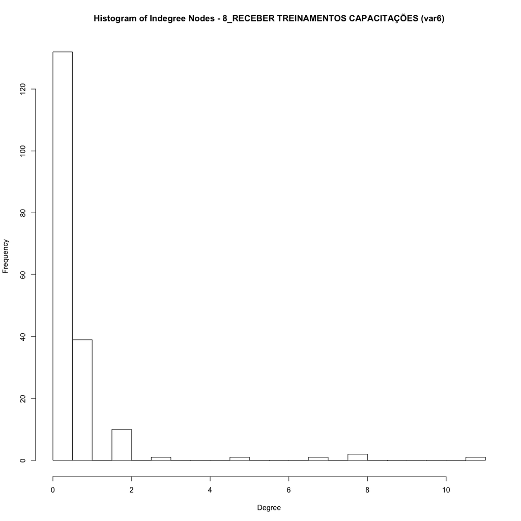

```r
hist(degree(var6, mode = "in", normalized = F), ylab="Frequency", xlab="Degree",  breaks=vcount(var6)/10, main="Histogram of Indegree Nodes - 8_RECEBER TREINAMENTOS CAPACITAÇÕES (var6)")
```

## 4.3 Centrality Degree Descriptive Statistics - Out

```r
##out
summary(var6_outdegree)
```

```
##    Min. 1st Qu.  Median    Mean 3rd Qu.    Max.
##  0.0000  0.0000  0.0000  0.5401  0.0000 35.0000
```

```r
sd(var6_outdegree)
```

```
## [1] 2.644175
```

## 4.4 Histogram var6 degree - Out

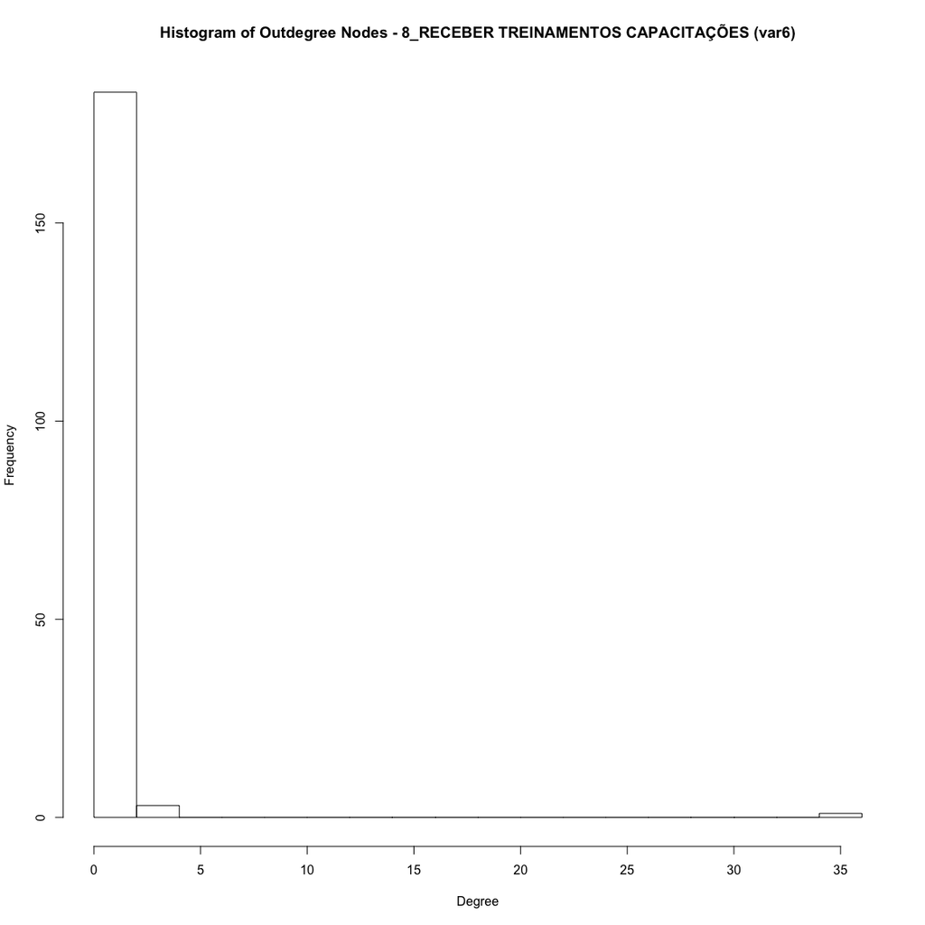

```r
hist(degree(var6, mode = "out", normalized = F), ylab="Frequency", xlab="Degree",  breaks=vcount(var6)/10, main="Histogram of Outdegree Nodes - 8_RECEBER TREINAMENTOS CAPACITAÇÕES (var6)")
```

## 4.5 Centrality Degree Descriptive Statistics - All

```r
##all
summary(var6_totaldegree)
```

```
##    Min. 1st Qu.  Median    Mean 3rd Qu.    Max.
##    0.00    0.00    0.00    1.08    1.00   35.00
```

```r
sd(var6_totaldegree)
```

```
## [1] 2.927251
```

## 4.6 Histogram var6 degree - All

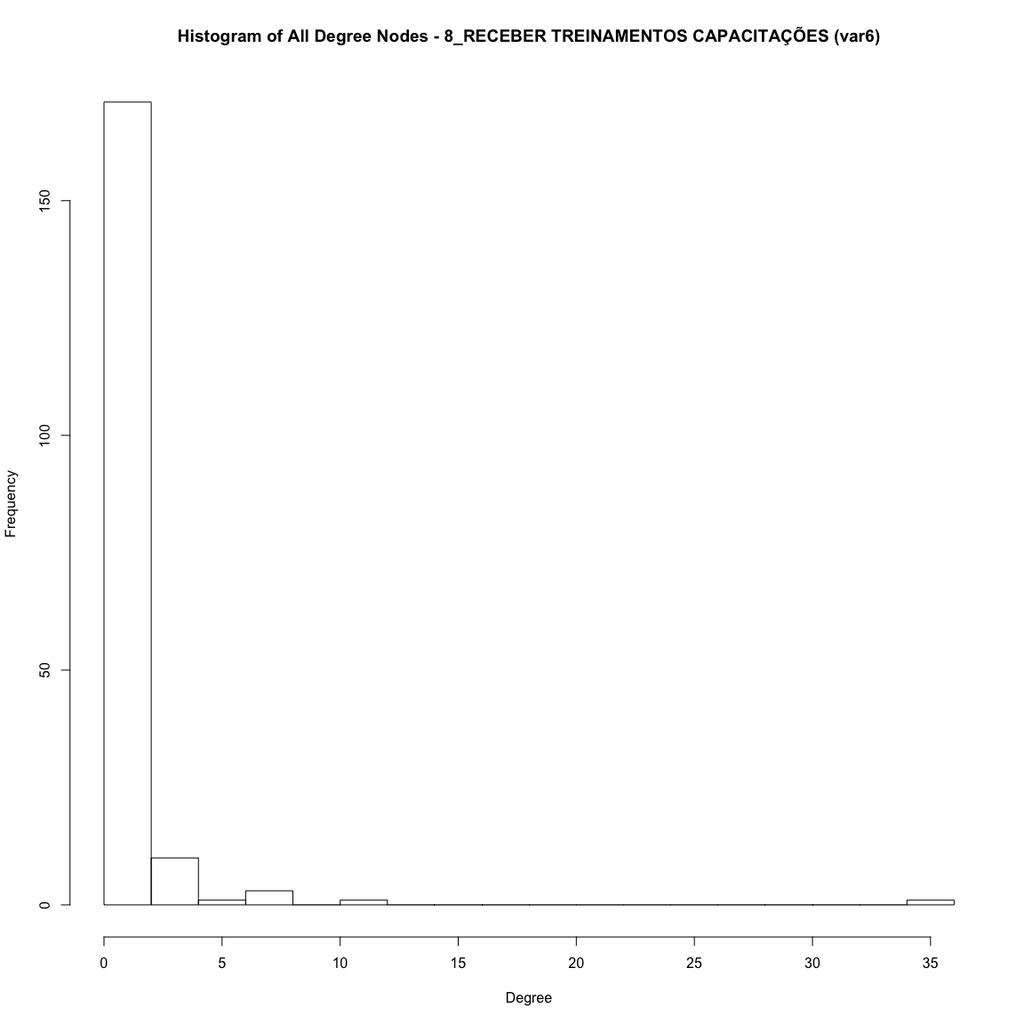

```r
hist(degree(var6, mode = "all", normalized = F), ylab="Frequency", xlab="Degree",  breaks=vcount(var6)/10, main="Histogram of All Degree Nodes - 8_RECEBER TREINAMENTOS CAPACITAÇÕES (var6)")
```

# 5 Compute strength - weighted

A slightly more nuanced metric is “strength centrality”, which is defined as the sum of the weights of all the connections for a given node. This is also sometimes called “weighted degree centrality”

```r
V(var6)$var6_strength<- strength(var6, weights=E(var6)$weight)
var6_strength<- strength(var6, weights=E(var6)$weight)
```

## 5.1 Strength Stats

```r
summary(var6_strength)
```

```
##    Min. 1st Qu.  Median    Mean 3rd Qu.    Max.
##    0.00    0.00    0.00    1.08    1.00   35.00
```

```r
sd(var6_strength)
```

```
## [1] 2.927251
```

## 5.2 Histogram var6 degree - All

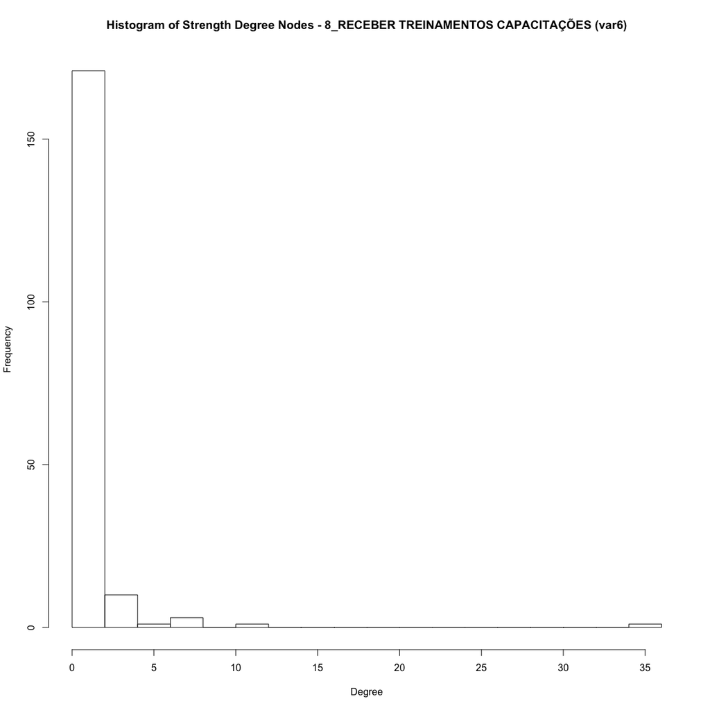

```r
hist(strength(var6, weights=E(var6)$weight), ylab="Frequency", xlab="Degree",  breaks=vcount(var6)/10, main="Histogram of Strength Degree Nodes - 8_RECEBER TREINAMENTOS CAPACITAÇÕES (var6)")
```

# 6 Centrality Degree Normalized

## 6.1 Centrality Degree Normalized saving igraph object

```r
V(var6)$indegree_n<-degree(var6, mode = "in", normalized = T)
V(var6)$outdegree_n<- degree(var6, mode = "out", normalized = T)
V(var6)$totaldegree_n<- degree(var6, mode = "total", normalized = T)
```

## 6.2 Saving in Global Environment as an object

```r
var6_indegree_n<-degree(var6, mode = "in", normalized = T)
var6_outdegree_n<-degree(var6, mode = "out", normalized = T)
var6_totaldegree_n<-degree(var6, mode = "total", normalized = T)
```

## 6.3 Centrality Degree Normalized Descriptive Statistics - in

```r
summary(var6_indegree_n)
```

```
##     Min.  1st Qu.   Median     Mean  3rd Qu.     Max.
## 0.000000 0.000000 0.000000 0.002904 0.005376 0.059140
```

```r
sd(var6_indegree_n)
```

```
## [1] 0.007442681
```

## 6.4 Histogram var6 degree normalized - in

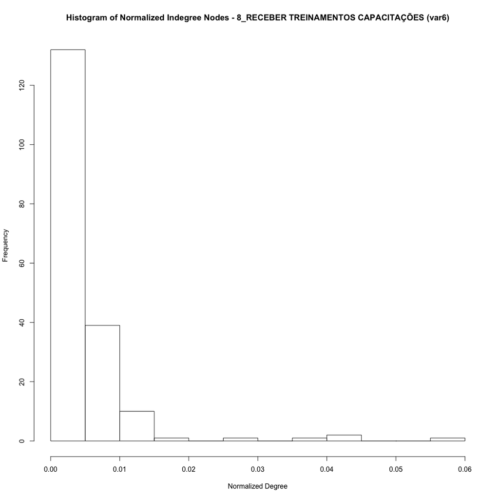

```r
hist(degree(var6, mode = "in", normalized = T), ylab="Frequency", xlab="Normalized Degree",  breaks=vcount(var6)/10, main="Histogram of Normalized Indegree Nodes - 8_RECEBER TREINAMENTOS CAPACITAÇÕES (var6)")
```

## 6.5 Centrality Degree Normalized Descriptive Statistics - out

```r
summary(var6_outdegree_n)
```

```
##     Min.  1st Qu.   Median     Mean  3rd Qu.     Max.
## 0.000000 0.000000 0.000000 0.002904 0.000000 0.188200
```

```r
sd(var6_outdegree_n)
```

```
## [1] 0.014216
```

## 6.6 Histogram var6 degree normalized - out

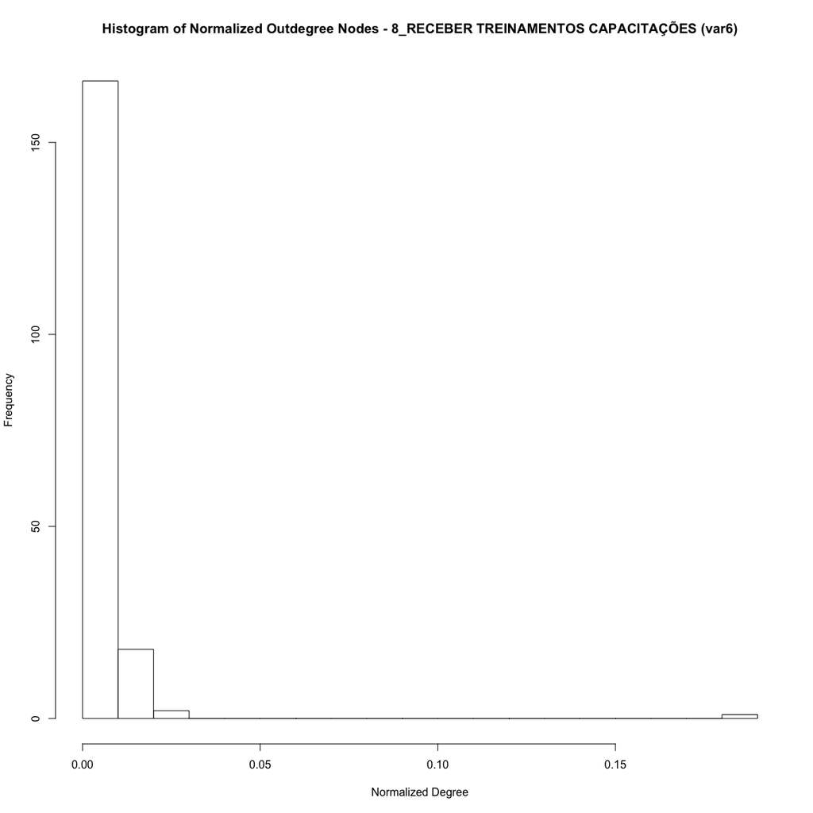

```r
hist(degree(var6, mode = "out", normalized = T), ylab="Frequency", xlab="Normalized Degree",  breaks=vcount(var6)/10, main="Histogram of Normalized Outdegree Nodes - 8_RECEBER TREINAMENTOS CAPACITAÇÕES (var6)")
```

## 6.7 Centrality Degree Normalized Descriptive Statistics - all

```r
summary(var6_totaldegree_n)
```

```
##     Min.  1st Qu.   Median     Mean  3rd Qu.     Max.
## 0.000000 0.000000 0.000000 0.005808 0.005376 0.188200
```

```r
sd(var6_totaldegree_n)
```

```
## [1] 0.01573791
```

## 6.8 Histogram var6 degree normalized - all

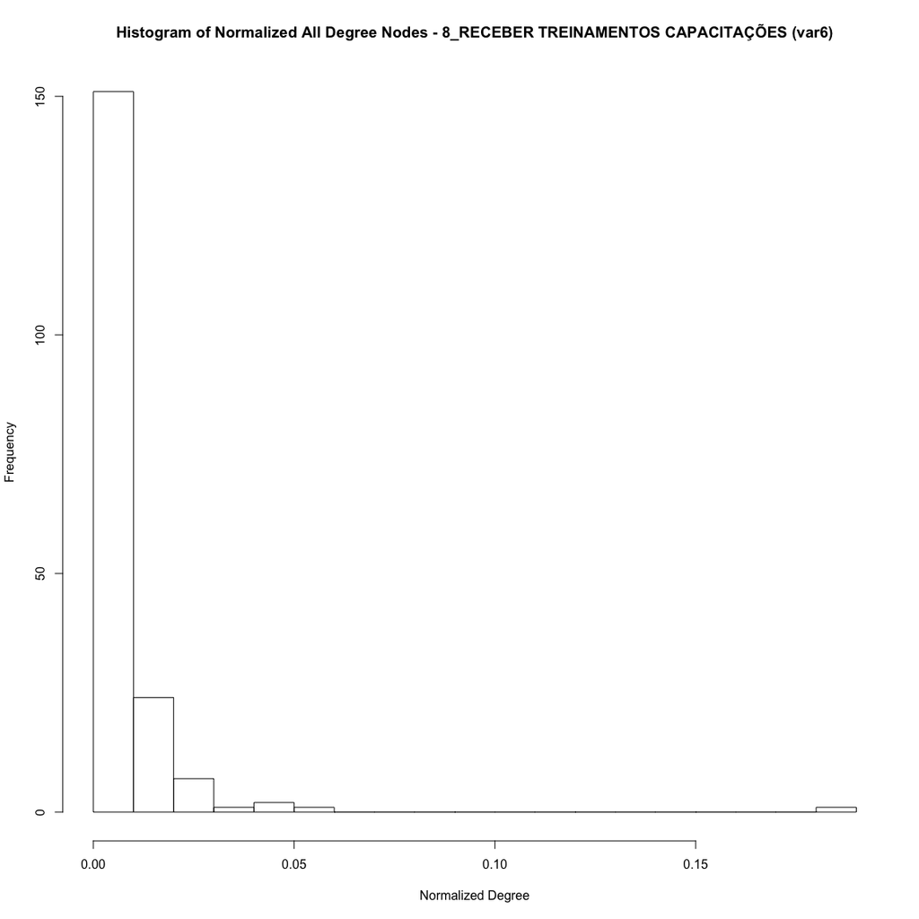

```r
hist(degree(var6, mode = "all", normalized = T), ylab="Frequency", xlab="Normalized Degree",  breaks=vcount(var6)/10, main="Histogram of Normalized All Degree Nodes - 8_RECEBER TREINAMENTOS CAPACITAÇÕES (var6)")
```

# 7 Centralization Degree

```r
V(var6)$var6_centr_degree <- centralization.degree(var6)$res
var6_centr_degree <- centralization.degree(var6)
```

## 7.1 Centralization

```r
var6_centr_degree$centralization
```

```
## [1] 0.09167245
```

## 7.2 Theoretical Max

```r
var6_centr_degree$theoretical_max
```

```
## [1] 69192
```

# 8 Degree distribution considering total equal one

```r
var6_degree.distribution<-degree.distribution(var6)
```

## 8.1 Degree distribution Descriptive Stats

```r
summary(var6_degree.distribution)
```

```
##     Min.  1st Qu.   Median     Mean  3rd Qu.     Max.
## 0.000000 0.000000 0.000000 0.027780 0.005348 0.529400
```

```r
sd(var6_degree.distribution)
```

```
## [1] 0.09899194
```

## 8.2 Histogram var6 distribution degree

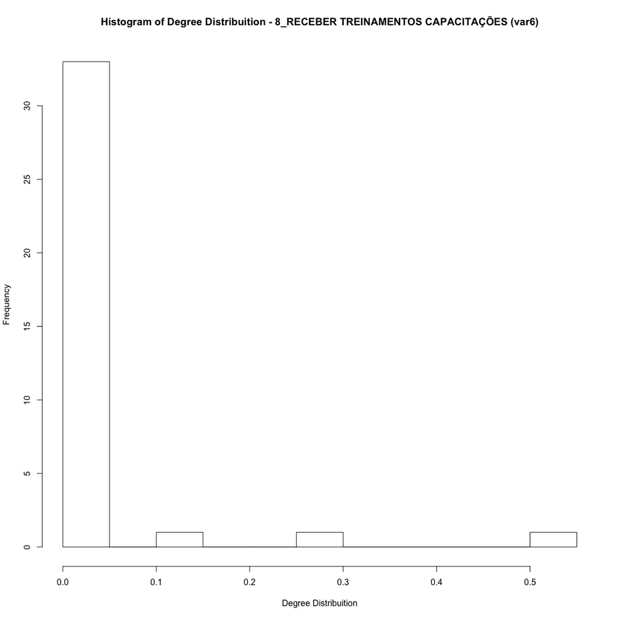

```r
hist(degree.distribution(var6), breaks=vcount(var6)/10, ylab="Frequency", xlab="Degree Distribuition", main="Histogram of Degree Distribuition - 8_RECEBER TREINAMENTOS CAPACITAÇÕES (var6)")
```

## 8.3 Degree Probability Distribution

```r
dd <- degree.distribution(var6, cumulative=T, mode="all")
```

## 8.4 Degree Probability Distribution - Plot Cumulative Frequency

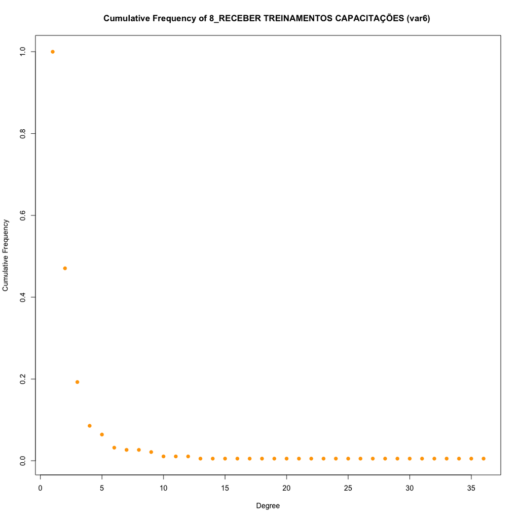

```r
plot(dd, pch=19, cex=1, col="orange", xlab="Degree", ylab="Cumulative Frequency", main= "Cumulative Frequency of 8_RECEBER TREINAMENTOS CAPACITAÇÕES (var6) ")
```

# 9 Log-Log Degree Distribution - Scale Free Network - Does it fit to power law ?

```r
dd.var6 <- degree.distribution(var6)
d <- 1:max(degree(var6))-1
ind <- (dd.var6 != 0)
```

## 9.1 Plot Log-Log Degree Distribution

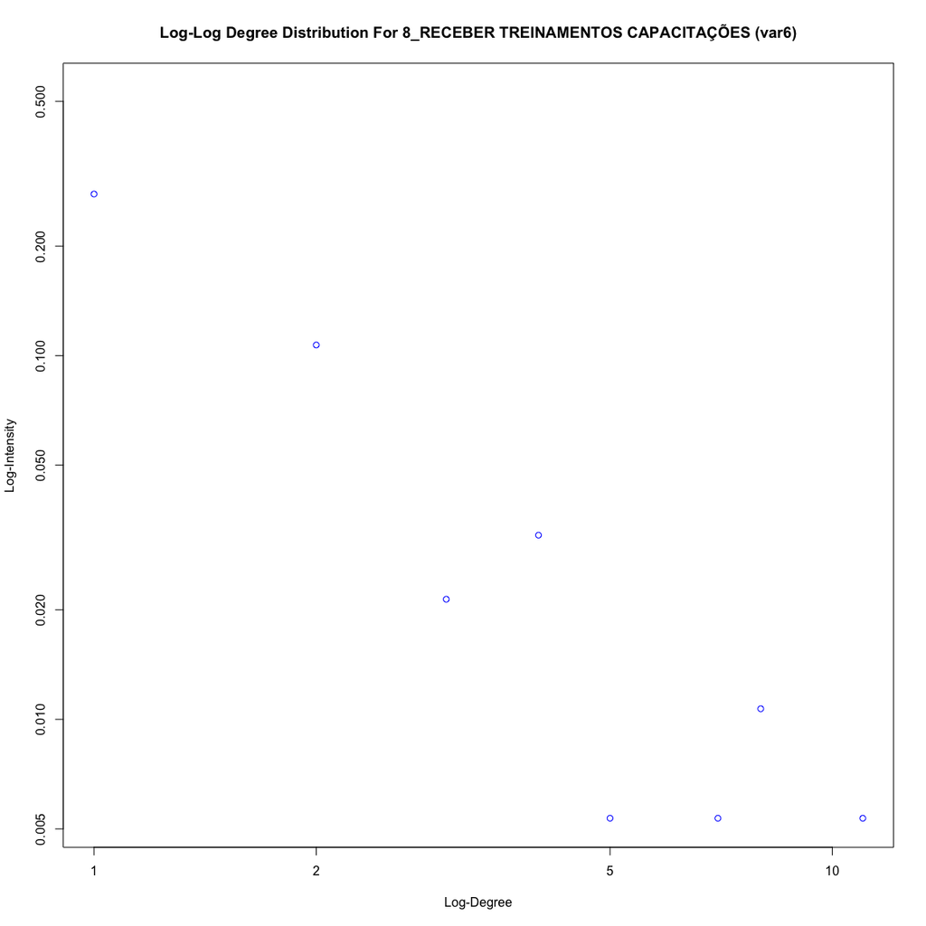

```r
plot(d[ind],
     dd.var6[ind],
     log="xy",
     col="blue",
     xlab=c("Log-Degree"),
     ylab=c("Log-Intensity"),
     main="Log-Log Degree Distribution For 8_RECEBER TREINAMENTOS CAPACITAÇÕES (var6)"
     )
```

# 10 Average Neighbor Degree versus Vertex Degree (log-log scale for 8_RECEBER TREINAMENTOS CAPACITAÇÕES (var6))

The neighborhood of a given order y of a vertex v includes all vertices which are closer to v than the order. Ie. order y=0 is always v itself, order 1 is v plus its immediate neighbors, order 2 is order 1 plus the immediate neighbors of the vertices in order 1, etc.

## 10.1 Average Neighbor Degree versus vertex degree (log-log scale for var6)

```r
var6_a.nn.deg <- graph.knn(var6, weights =E(var6)$weight)$knn %>% round(1)
```

## 10.2 Saving to igraph object

```r
V(var6)$var6_a.nn.deg <- graph.knn(var6, weights=E(var6)$weight)$knn
```

## 10.3 Table Average Neighbor Degree

```r
d<-cbind(V(var6)$LABEL_COR,var6_a.nn.deg)
datatable(d)
```

|  | V1 | var6_a.nn.deg |
| --- | --- | --- |
| ASS_HOS_ Hospital de Pronto Socorro – HPS | Assistência Hospitalar | NaN |
| AMB_SAM_ Centro de Atenção à Saúde Mental (CASM) | Ambulatório de Saúde Mental | 4 |
| CAPS_AD | CAPSAD | 2.3 |
| CRAS_AS_ CRAS Sudeste Costa Carvalho | CRAS/CREAS | 2.5 |
| CRE_SOC_ CREAS Infância e Juventude | CRAS/CREAS | NaN |
| CRE_SOC_ CREAS Norte | CRAS/CREAS | NaN |
| ASS_HOS_ Serviço de Controle e Prevenção e Tratamento do Tabagismo (SECOPTT) | Assistência Hospitalar | 1.9 |
| EA_DQCT_ Centro de Recuperação Resgatando Vidas (Escritório) | Entidades Assistênciais e Dependencia Química e CT | 4 |
| EA_DQCT_ Comunidade Terapêutica Geração de Adoradores – CTGA | Entidades Assistênciais e Dependencia Química e CT | NaN |
| EA_DQCT_ Centro de Recuperação Resgatando Vidas | Entidades Assistênciais e Dependencia Química e CT | 3 |

[output cut: 177 more lines]

## 10.4 Plotting Average Neighbor Degree versus vertex degree

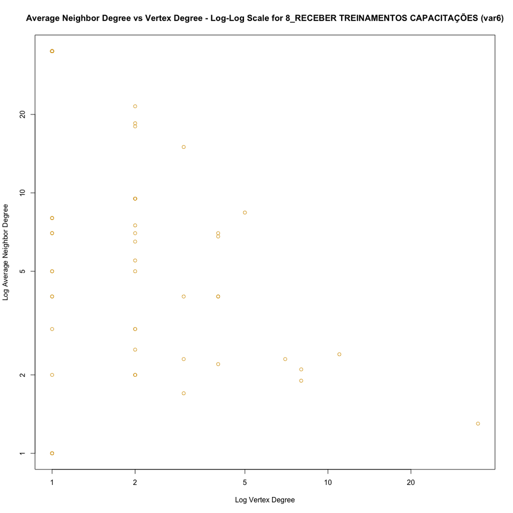

```r
plot(degree(var6),
     var6_a.nn.deg,
     log="xy",
     col="goldenrod",
     xlab=c("Log Vertex Degree"),
     ylab=c("Log Average Neighbor Degree"),
     main="Average Neighbor Degree vs Vertex Degree - Log-Log Scale for 8_RECEBER TREINAMENTOS CAPACITAÇÕES (var6)"
     )
```

# 11 Average Weighted Neighbor Degree versus vertex degree (log-log scale for weighted 8_RECEBER TREINAMENTOS CAPACITAÇÕES (var6))

```r
var6_a.nn.deg_w <- graph.knn(var6,V(var6), weights=E(var6)$weight)$knn %>% round(1)
```

## 11.1 Saving to igraph object

```r
V(var6)$var6_a.nn.deg_w <-var6_a.nn.deg <- graph.knn(var6,V(var6), weights=E(var6)$weight)$knn
```

## 11.2 Average Weighted Neighbor Descriptive

```r
summary(var6_a.nn.deg_w)
```

```
##    Min. 1st Qu.  Median    Mean 3rd Qu.    Max.    NA's
##    1.00    3.75    8.00   15.68   35.00   35.00      99
```

```r
sd(var6_a.nn.deg_w, na.rm = T)
```

```
## [1] 14.43753
```

## 11.3 Table Average Neighbor Degree Weighted

```r
d<-cbind(V(var6)$LABEL_COR,var6_a.nn.deg_w)
datatable(d)
```

|  | V1 | var6_a.nn.deg_w |
| --- | --- | --- |
| ASS_HOS_ Hospital de Pronto Socorro – HPS | Assistência Hospitalar | NaN |
| AMB_SAM_ Centro de Atenção à Saúde Mental (CASM) | Ambulatório de Saúde Mental | 4 |
| CAPS_AD | CAPSAD | 2.3 |
| CRAS_AS_ CRAS Sudeste Costa Carvalho | CRAS/CREAS | 2.5 |
| CRE_SOC_ CREAS Infância e Juventude | CRAS/CREAS | NaN |
| CRE_SOC_ CREAS Norte | CRAS/CREAS | NaN |
| ASS_HOS_ Serviço de Controle e Prevenção e Tratamento do Tabagismo (SECOPTT) | Assistência Hospitalar | 1.9 |
| EA_DQCT_ Centro de Recuperação Resgatando Vidas (Escritório) | Entidades Assistênciais e Dependencia Química e CT | 4 |
| EA_DQCT_ Comunidade Terapêutica Geração de Adoradores – CTGA | Entidades Assistênciais e Dependencia Química e CT | NaN |
| EA_DQCT_ Centro de Recuperação Resgatando Vidas | Entidades Assistênciais e Dependencia Química e CT | 3 |

[output cut: 177 more lines]

## 11.4 Plotting Average Neighbor Degree versus vertex degree

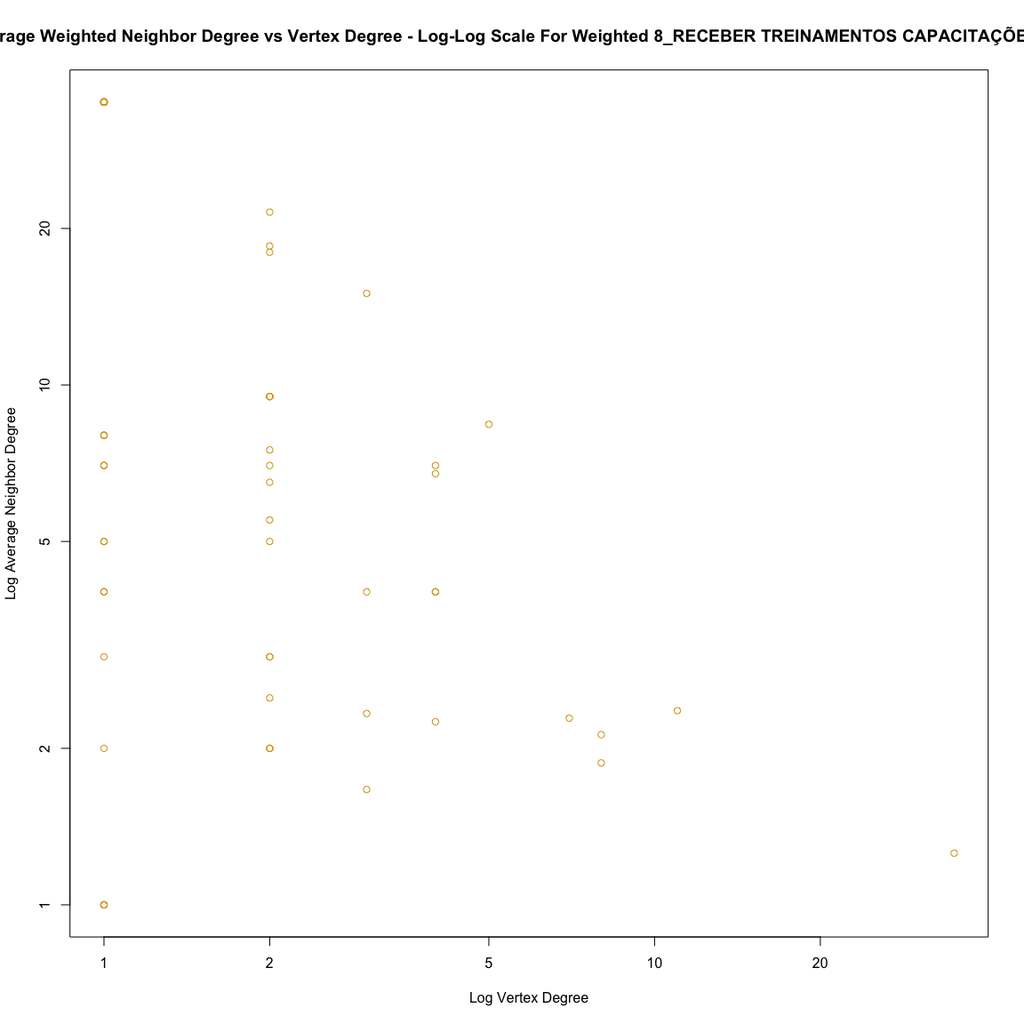

```r
plot(degree(var6),
     var6_a.nn.deg,
     log="xy",
     col="goldenrod",
     xlab=c("Log Vertex Degree"),
     ylab=c("Log Average Neighbor Degree"),
     main="Average Weighted Neighbor Degree vs Vertex Degree - Log-Log Scale For Weighted 8_RECEBER TREINAMENTOS CAPACITAÇÕES (var6)"
     )
```

# 12 Degree Centralities Dinamic Table

## 12.1 Getting Degree Measures

```r
var6_indegree<-degree(var6, mode = "in")
var6_outdegree<-degree(var6, mode = "out")
var6_totaldegree<-degree(var6, mode = "total")
var6_strength<- strength(var6, weights=E(var6)$weight)
var6_indegree_n<-degree(var6, mode = "in", normalized = T) %>% round(3)
var6_outdegree_n<-degree(var6, mode = "out", normalized = T) %>% round(3)
var6_totaldegree_n<-degree(var6, mode = "total", normalized = T) %>% round(3)
var6_centr_degree <- centralization.degree(var6)$res
var6_a.nn.deg <- graph.knn(var6,V(var6))$knn %>% round(1)
var6_a.nn.deg_w <- graph.knn(var6,V(var6), weights=E(var6)$weight)$knn %>% round(1)
```

## 12.2 Creating a dataframe of measures

```r
var6_df_degree <- data.frame(var6_indegree,
var6_outdegree,
var6_totaldegree,
var6_indegree_n,
var6_outdegree_n,
var6_totaldegree_n,
var6_strength,
var6_centr_degree,
var6_a.nn.deg,
var6_a.nn.deg_w) %>% round(3)

#Adding type
var6_df_degree <-cbind(var6_df_degree, V(var6)$LABEL_COR)

#Adding names
names(var6_df_degree) <- c("In Degree", "Out Degree", "Total Degree","In Degree Normalized", "Out Degree Normalized", "Total Degree Normalized", "Strength","Centralization Degree","Average Neighbor Degree","Average Weighted Neighbor Degree","Type")

#Ordering Variables
var6_df_degree<-var6_df_degree[c("Type","In Degree", "Out Degree", "Total Degree","In Degree Normalized", "Out Degree Normalized", "Total Degree Normalized", "Strength","Centralization Degree","Average Neighbor Degree","Average Weighted Neighbor Degree")]
```

## 12.3 General tabel - DT

```r
datatable(var6_df_degree, filter = 'top')
```

|  | Type | In Degree | Out Degree | Total Degree | In Degree Normalized | Out Degree Normalized | Total Degree Normalized | Strength | Centralization Degree | Average Neighbor Degree | Average Weighted Neighbor Degree |
| --- | --- | --- | --- | --- | --- | --- | --- | --- | --- | --- | --- |
| ASS_HOS_ Hospital de Pronto Socorro – HPS | Assistência Hospitalar | 0 | 0 | 0 | 0 | 0 | 0 | 0 | 0 |  |  |
| AMB_SAM_ Centro de Atenção à Saúde Mental (CASM) | Ambulatório de Saúde Mental | 1 | 0 | 1 | 0.005 | 0 | 0.005 | 1 | 1 | 4 | 4 |
| CAPS_AD | CAPSAD | 7 | 0 | 7 | 0.038 | 0 | 0.038 | 7 | 7 | 2.3 | 2.3 |
| CRAS_AS_ CRAS Sudeste Costa Carvalho | CRAS/CREAS | 0 | 2 | 2 | 0 | 0.011 | 0.011 | 2 | 2 | 2.5 | 2.5 |
| CRE_SOC_ CREAS Infância e Juventude | CRAS/CREAS | 0 | 0 | 0 | 0 | 0 | 0 | 0 | 0 |  |  |
| CRE_SOC_ CREAS Norte | CRAS/CREAS | 0 | 0 | 0 | 0 | 0 | 0 | 0 | 0 |  |  |
| ASS_HOS_ Serviço de Controle e Prevenção e Tratamento do Tabagismo (SECOPTT) | Assistência Hospitalar | 8 | 0 | 8 | 0.043 | 0 | 0.043 | 8 | 8 | 1.9 | 1.9 |
| EA_DQCT_ Centro de Recuperação Resgatando Vidas (Escritório) | Entidades Assistênciais e Dependencia Química e CT | 1 | 2 | 3 | 0.005 | 0.011 | 0.016 | 3 | 3 | 4 | 4 |
| EA_DQCT_ Comunidade Terapêutica Geração de Adoradores – CTGA | Entidades Assistênciais e Dependencia Química e CT | 0 | 0 | 0 | 0 | 0 | 0 | 0 | 0 |  |  |
| EA_DQCT_ Centro de Recuperação Resgatando Vidas | Entidades Assistênciais e Dependencia Química e CT | 2 | 0 | 2 | 0.011 | 0 | 0.011 | 2 | 2 | 3 | 3 |

[output cut: 177 more lines]

## 12.4 Aggregating data from previous table - mean

```r
aggdata_mean <-aggregate(var6_df_degree, by=list(var6_df_degree$Type), FUN=mean, na.rm=TRUE)

#Removing Type variable
aggdata_mean<-aggdata_mean[,-c(2)]
names(aggdata_mean) <- c("Group", "In Degree(M)", "Out Degree(M)", "Total Degree(M)","In Degree Normalized(M)", "Out Degree Normalized(M)", "Total Degree Normalized(M)", "Strength(M)","Centralization Degree(M)","Average Neighbor Degree(M)","Average Weighted Neighbor Degree(M)")
```

## 12.5 Aggregating data from previous table - sd

```r
aggdata_sd <-aggregate(var6_df_degree, by=list(var6_df_degree$Type), FUN=sd, na.rm=TRUE)

#Removing Type variable
aggdata_sd<-aggdata_sd[,-c(2)]
names(aggdata_sd) <- c("Group", "In Degree(SD)", "Out Degree(SD)", "Total Degree(SD)","In Degree Normalized(SD)", "Out Degree Normalized(SD)", "Total Degree Normalized(SD)", "Strength(SD)","Centralization Degree(SD)","Average Neighbor Degree(SD)","Average Weighted Neighbor Degree(SD)")
```

## 12.6 Merging mean and standart deviation

```r
total <- merge(aggdata_mean,aggdata_sd,by="Group")

#Rounding
Group<-total[,c(1)] #Keeping group
total<-total[,-c(1)] %>% round(2) #Rouding
total<-cbind(Group,total) #Binding toghter

#Organizing Variabels
total<-total[c("Group","In Degree(M)","In Degree(SD)", "Out Degree(M)", "Out Degree(SD)","Total Degree(M)", "Total Degree(SD)", "In Degree Normalized(M)", "In Degree Normalized(SD)", "Out Degree Normalized(M)", "Out Degree Normalized(SD)", "Total Degree Normalized(M)", "Total Degree Normalized(SD)", "Strength(M)","Strength(SD)", "Centralization Degree(M)","Centralization Degree(SD)","Average Neighbor Degree(M)","Average Neighbor Degree(SD)","Average Weighted Neighbor Degree(M)", "Average Weighted Neighbor Degree(SD)")]
```

## 12.7 Plotting final table with round

```r
datatable(total, filter = 'top')
```

|  | Group | In Degree(M) | In Degree(SD) | Out Degree(M) | Out Degree(SD) | Total Degree(M) | Total Degree(SD) | In Degree Normalized(M) | In Degree Normalized(SD) | Out Degree Normalized(M) | Out Degree Normalized(SD) | Total Degree Normalized(M) | Total Degree Normalized(SD) | Strength(M) | Strength(SD) | Centralization Degree(M) | Centralization Degree(SD) | Average Neighbor Degree(M) | Average Neighbor Degree(SD) | Average Weighted Neighbor Degree(M) | Average Weighted Neighbor Degree(SD) |
| --- | --- | --- | --- | --- | --- | --- | --- | --- | --- | --- | --- | --- | --- | --- | --- | --- | --- | --- | --- | --- | --- |
| 1 | Acolhimento Institucional | 0 | 0 | 0 | 0 | 0 | 0 | 0 | 0 | 0 | 0 | 0 | 0 | 0 | 0 | 0 | 0 |  |  |  |  |
| 2 | Ajuda Mútua | 0.91 | 0.81 | 0.87 | 5.15 | 1.78 | 5.07 | 0 | 0 | 0 | 0.03 | 0.01 | 0.03 | 1.78 | 5.07 | 1.78 | 5.07 | 29.43 | 10.85 | 29.43 | 10.85 |
| 3 | Ambulatório de Saúde Mental | 1 |  | 0 |  | 1 |  | 0 |  | 0 |  | 0 |  | 1 |  | 1 |  | 4 |  | 4 |  |
| 4 | Assistência Hospitalar | 1.14 | 3.02 | 0 | 0 | 1.14 | 3.02 | 0.01 | 0.02 | 0 | 0 | 0.01 | 0.02 | 1.14 | 3.02 | 1.14 | 3.02 | 1.9 |  | 1.9 |  |
| 5 | CAPS | 3.5 | 5.2 | 0 | 0 | 3.5 | 5.2 | 0.02 | 0.03 | 0 | 0 | 0.02 | 0.03 | 3.5 | 5.2 | 3.5 | 5.2 | 2.05 | 0.49 | 2.05 | 0.49 |
| 6 | CAPSAD | 7 |  | 0 |  | 7 |  | 0.04 |  | 0 |  | 0.04 |  | 7 |  | 7 |  | 2.3 |  | 2.3 |  |
| 7 | Consultório na Rua | 0 | 0 | 0 | 0 | 0 | 0 | 0 | 0 | 0 | 0 | 0 | 0 | 0 | 0 | 0 | 0 |  |  |  |  |
| 8 | CRAS/CREAS | 0.23 | 0.6 | 0.15 | 0.55 | 0.38 | 0.77 | 0 | 0 | 0 | 0 | 0 | 0 | 0.38 | 0.77 | 0.38 | 0.77 | 3.17 | 0.76 | 3.17 | 0.76 |
| 9 | Entidades Assistênciais e Dependencia Química e CT | 0.63 | 0.83 | 0.74 | 0.99 | 1.37 | 1.5 | 0 | 0 | 0 | 0.01 | 0.01 | 0.01 | 1.37 | 1.5 | 1.37 | 1.5 | 2.27 | 1.42 | 2.27 | 1.42 |
| 10 | Entidades Socioassistenciais | 1.27 | 2.37 | 0.55 | 0.82 | 1.82 | 2.44 | 0.01 | 0.01 | 0 | 0 | 0.01 | 0.01 | 1.82 | 2.44 | 1.82 | 2.44 | 2.88 | 2.02 | 2.88 | 2.02 |

[output cut: 3 more lines]

# 13 Network plotting based only on degree measures

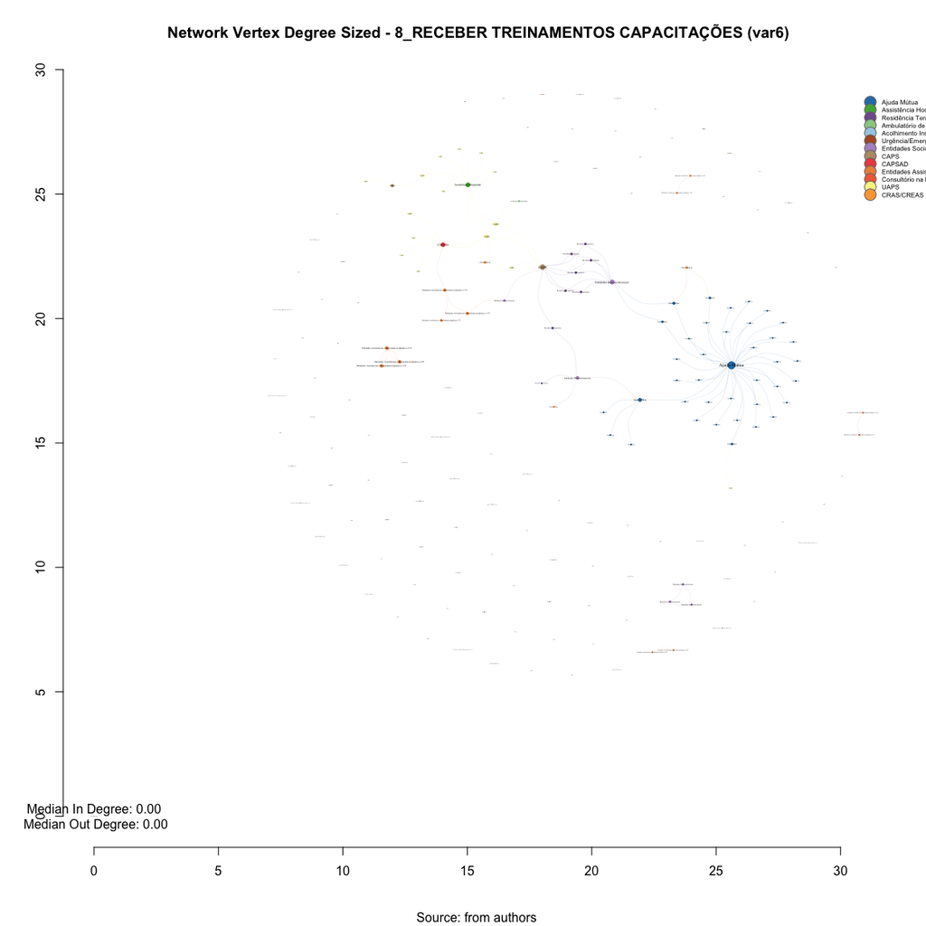

```r
#Set Seed
set.seed(123)
#Plotting based only on degree measures
edge.start <- ends(var6, es=E(var6), names=F)[,1]

# Fixing ego
minC <- rep(-Inf, vcount(var6))
maxC <- rep(Inf, vcount(var6))
minC[1] <- maxC[1] <- 0
co <- layout_with_fr(var6, niter=10000, minx=minC, maxx=maxC,miny=minC, maxy=maxC, weights = E(var6)$weight)

#PLotting
plot(var6,
     layout=co,
     edge.color=V(var6)$color[edge.start],
     edge.arrow.size=(degree(var6)+1)/1000,
     edge.width=E(var6)$weight/10,
     edge.curved = TRUE,
     vertex.size=log((degree(var6)+2))*10,
     vertex.size=20,
     vertex.frame.color="#ffffff",
     vertex.label.color="black",
     vertex.label=get.vertex.attribute(var6,"LABEL_COR"),
     vertex.label.cex=log((degree(var6)+2))/10,
     vertex.label.dist=0,
     rescale=F,
     xlim=range(co[,1]),
     ylim=range(co[,2]))
axis(1)
axis(2)


#Solving Problems with legend rendering
a<-V(var6)$LABEL_COR
b<-V(var6)$color
c<-table(a,b)
d<-as.data.frame(c)
e<-subset(d, d$Freq>0)
f<-t(e$a)
g<-t(e$b)

#Adding Legend
legend(x=range(co[,1])[2], y=range(co[,2])[2],
       legend=as.character(f),
       pch=21,
       col = "#777777",
       pt.bg=as.character(g),
       pt.cex=2,
       bty="n",
       ncol=1,
       lty=1,
       cex = .5)

#Adding Title
  title("Network Vertex Degree Sized - 8_RECEBER TREINAMENTOS CAPACITAÇÕES (var6)", sub = "Source: from authors ", cex = .5)
  text(x=range(co[,1])[1], y=range(co[,2])[1], labels =
   sprintf("Median In Degree: %.2f\n Median Out Degree: %.2f",
     median(degree(var6, mode="in")),
     median(degree(var6, mode="out"))
   ))
```

# 14 Network plotting based only on degree measures

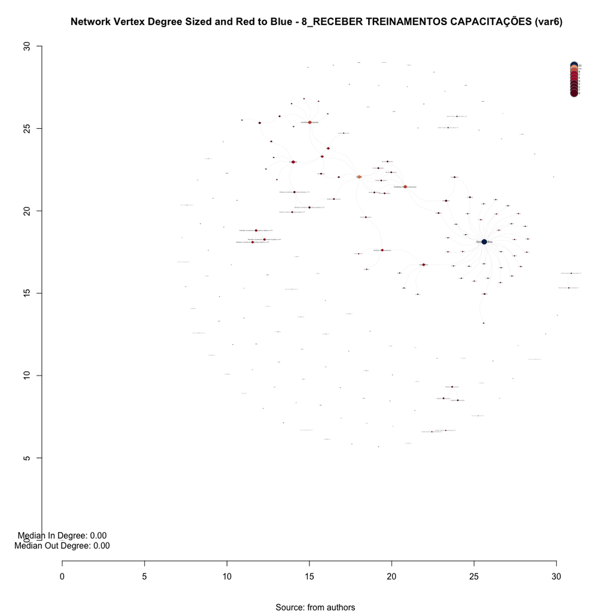

```r
#Set Seed
set.seed(123)

#Get Variable
V(var6)$var6_color_degree<-V(var6)$totaldegree %>% round(0)

#Creating brewer pallette
vertex_var6_color_degree<-
  colorRampPalette(brewer.pal(length(unique(
          V(var6)$var6_color_degree)), "RdBu"))(
            length(unique(V(var6)$var6_color_degree)))

#Saving as Vertex properties
V(var6)$vertex_var6_color_degree<- vertex_var6_color_degree[as.numeric(cut(degree(var6),breaks =length(unique(V(var6)$var6_color_degree))))]

set.seed(123)
#Plotting based only on degree measures
edge.start <- ends(var6, es=E(var6), names=F)[,1]

# Fixing ego
minC <- rep(-Inf, vcount(var6))
maxC <- rep(Inf, vcount(var6))
minC[1] <- maxC[1] <- 0
co <- layout_with_fr(var6, niter=10000, minx=minC, maxx=maxC,miny=minC, maxy=maxC, weights = E(var6)$weight)

#PLotting
plot(var6,
     layout=co,
     #edge.color=V(var6)$color[edge.start],
     edge.arrow.size=(degree(var6)+1)/1000,
     edge.width=E(var6)$weight/10,
     edge.curved = TRUE,
     vertex.color=V(var6)$vertex_var6_color_degree,
     vertex.size=log((degree(var6)+2))*10,
     vertex.size=20,
     vertex.frame.color="#ffffff",
     vertex.label.color="black",
     vertex.label=get.vertex.attribute(var6,"LABEL_COR"),
     vertex.label.cex=log((degree(var6)+2))/10,
     vertex.label.dist=0,
     rescale=F,
     xlim=range(co[,1]),
     ylim=range(co[,2]))
axis(1)
axis(2)


#Solving Problems with legend rendering
a<-V(var6)$var6_color_degree
b<-V(var6)$vertex_var6_color_degree
c<-table(a,b)
d<-as.data.frame(c)
e<-subset(d, d$Freq>0)
e<-e[order(e$a,decreasing=T),]
f<-t(e$a)
g<-t(e$b)

#Adding Legend
legend(x=range(co[,1])[2], y=range(co[,2])[2],
       legend=as.character(f),
       pch=21,
       col = "#777777",
       pt.bg=as.character(g),
       pt.cex=2,
       bty="n",
       ncol=1,
       lty=1,
       cex = .3)

#Adding Title
  title("Network Vertex Degree Sized and Red to Blue - 8_RECEBER TREINAMENTOS CAPACITAÇÕES (var6)", sub = "Source: from authors ")
  text(x=range(co[,1])[1], y=range(co[,2])[1], labels =
   sprintf("Median In Degree: %.2f\nMedian Out Degree: %.2f",
     median(degree(var6, mode="in")),
     median(degree(var6, mode="out"))
   ))
```

# 15 Network Plotting Centralization - Degree Measures - Using Spectral Color as Distance Measure Representation

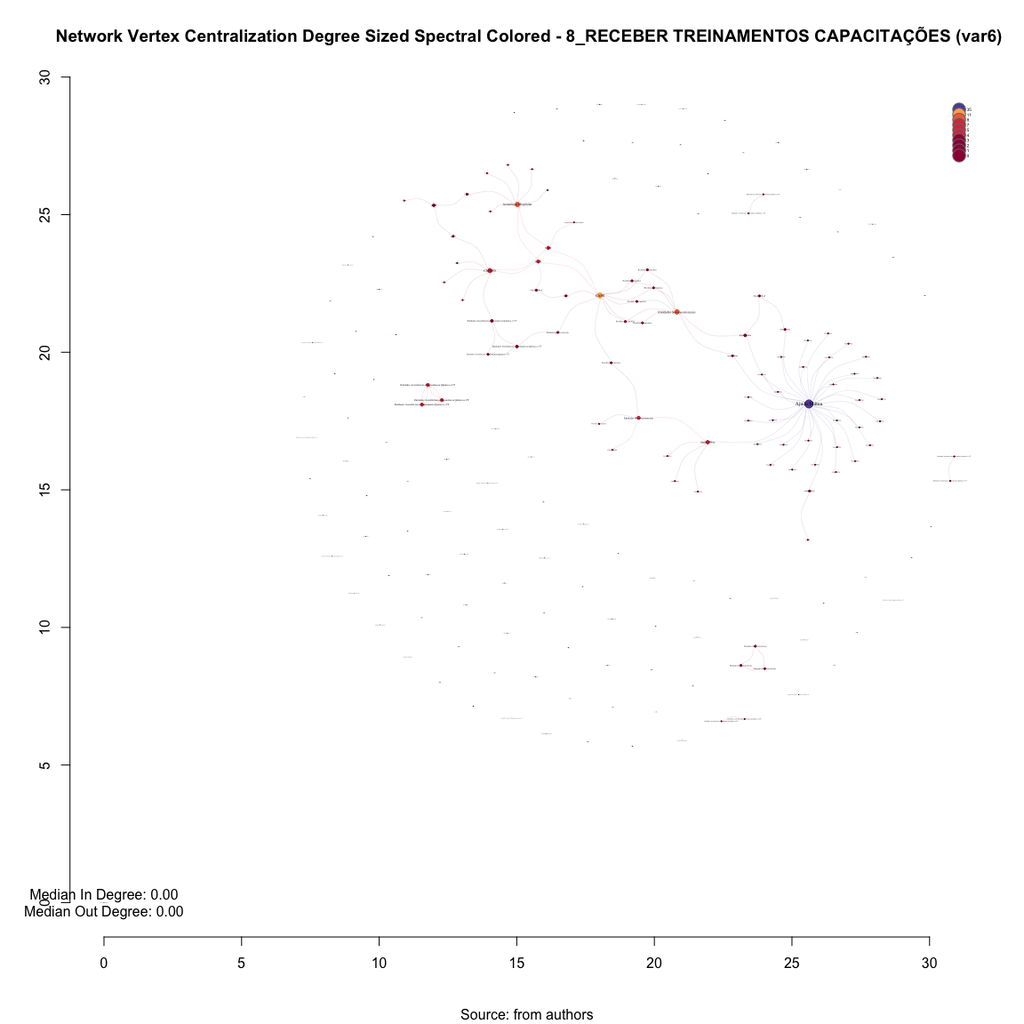

```r
#Set Seed
set.seed(123)

#Get Variable
V(var6)$var6_color_degree<-V(var6)$var6_centr_degree

#Creating brewer pallette
vertex_var6_color_degree<-
  colorRampPalette(brewer.pal(length(unique(
          V(var6)$var6_color_degree)), "Spectral"))(
            length(unique(V(var6)$var6_color_degree)))

#Saving as Vertex properties
V(var6)$vertex_var6_color_degree<- vertex_var6_color_degree[as.numeric(cut(V(var6)$var6_color_degree,breaks =length(unique(V(var6)$var6_color_degree))))]

#Plotting based only on degree measures
edge.start <- ends(var6, es=E(var6), names=F)[,1]

# Fixing ego
minC <- rep(-Inf, vcount(var6))
maxC <- rep(Inf, vcount(var6))
minC[1] <- maxC[1] <- 0
co <- layout_with_fr(var6, niter=10000, minx=minC, maxx=maxC,miny=minC, maxy=maxC, weights = E(var6)$weight)

#PLotting
plot(var6,
     layout=co,
     vertex.color=V(var6)$vertex_var6_color_degree,
     edge.color=V(var6)$vertex_var6_color_degree[edge.start],
     edge.arrow.size=(degree(var6)+1)/10000,
     edge.width=E(var6)$weight/10,
     edge.curved = TRUE,
     vertex.color=V(var6)$vertex_var6_color_degree,
    vertex.size=log((V(var6)$var6_centr_degree+2))*10,
     vertex.size=20,
     vertex.frame.color="#ffffff",
     vertex.label.color="black",
     vertex.label=get.vertex.attribute(var6,"LABEL_COR"),
     vertex.label.cex=log((degree(var6)+2))/10,
     vertex.label.dist=0,
     rescale=F,
     xlim=range(co[,1]),
     ylim=range(co[,2]))
axis(1)
axis(2)


#Solving Problems with legend rendering
a<-V(var6)$var6_color_degree
b<-V(var6)$vertex_var6_color_degree
c<-table(a,b)
d<-as.data.frame(c)
e<-subset(d, d$Freq>0)
e<-e[order(e$a,decreasing=T),]
f<-t(e$a)
g<-t(e$b)

#Adding Legend
legend(x=range(co[,1])[2], y=range(co[,2])[2],
       legend=as.character(f),
       pch=21,
       col = "#777777",
       pt.bg=as.character(g),
       pt.cex=2,
       bty="n",
       ncol=1,
       lty=1,
       cex = .3)

#Adding Title
  title("Network Vertex Centralization Degree Sized Spectral Colored - 8_RECEBER TREINAMENTOS CAPACITAÇÕES (var6)", sub = "Source: from authors ")
  text(x=range(co[,1])[1], y=range(co[,2])[1], labels =
   sprintf("Median In Degree: %.2f\nMedian Out Degree: %.2f",
     median(degree(var6, mode="in")),
     median(degree(var6, mode="out"))
   ))
```

# 16 Alternative vizualization using degree in order to genarete sub-graphs - Higher than median degree network

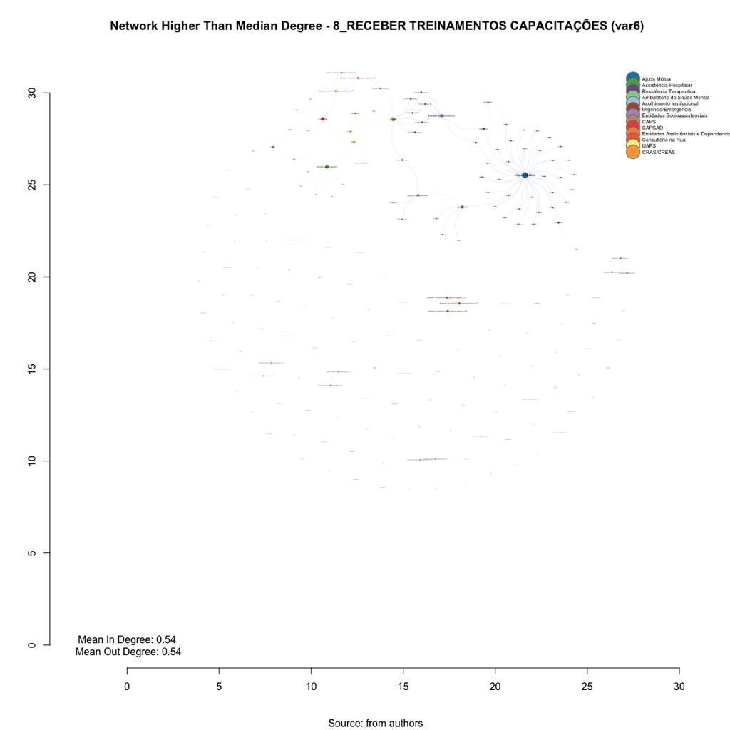

```r
#Set Seed
set.seed(124)

# Network elements with lower than meadian degree
higherthanmedian.network_var6<-V(var6)[degree(var6)<median(degree(var6))]

#Deleting vertices based in intersection betewenn var6
high_var6<-delete.vertices(var6, higherthanmedian.network_var6)

#Plotting based only on degree measures
edge.start <- ends(high_var6, es=E(high_var6), names=F)[,1]

# Fixing ego
minC <- rep(-Inf, vcount(high_var6))
maxC <- rep(Inf, vcount(high_var6))
minC[1] <- maxC[1] <- 0
co <- layout_with_fr(high_var6, niter=10000, minx=minC, maxx=maxC,miny=minC, maxy=maxC, weights = E(high_var6)$weight)

#PLotting
plot(high_var6,
     layout=co,
     edge.color=V(high_var6)$color[edge.start],
     edge.arrow.size=(degree(high_var6)+1)/1000,
     edge.width=E(high_var6)$weight/10,
     edge.curved = TRUE,
     vertex.size=log((V(high_var6)$var6_centr_degree+2))*10,
     vertex.frame.color="#ffffff",
     vertex.label.color="black",
     vertex.label=get.vertex.attribute(high_var6,"LABEL_COR"),
     vertex.label.cex=log((degree(high_var6)+2))/10,
     vertex.label.dist=0,
     rescale=F,
     xlim=range(co[,1]),
     ylim=range(co[,2]))
axis(1)
axis(2)


#Solving Problems with legend rendering
a<-V(high_var6)$LABEL_COR
b<-V(high_var6)$color
c<-table(a,b)
d<-as.data.frame(c)
e<-subset(d, d$Freq>0)
f<-t(e$a)
g<-t(e$b)

#Adding Legend
legend(x=range(co[,1])[2], y=range(co[,2])[2],
       legend=as.character(f),
       pch=21,
       col = "#777777",
       pt.bg=as.character(g),
       pt.cex=3,
       bty="n",
       ncol=1,
       lty=1,
       cex = .5)

#Adding Title
  title("Network Higher Than Median Degree - 8_RECEBER TREINAMENTOS CAPACITAÇÕES (var6)", sub = "Source: from authors ")
  text(x=range(co[,1])[1], y=range(co[,2])[1], labels =
   sprintf("Mean In Degree: %.2f\n Mean Out Degree: %.2f",
     mean(degree(high_var6, mode="in")),
     mean(degree(high_var6, mode="out"))
   )
  )
```

# 17 Alternative vizualization using degree in order to genarete sub-graphs - Lower than median degree network

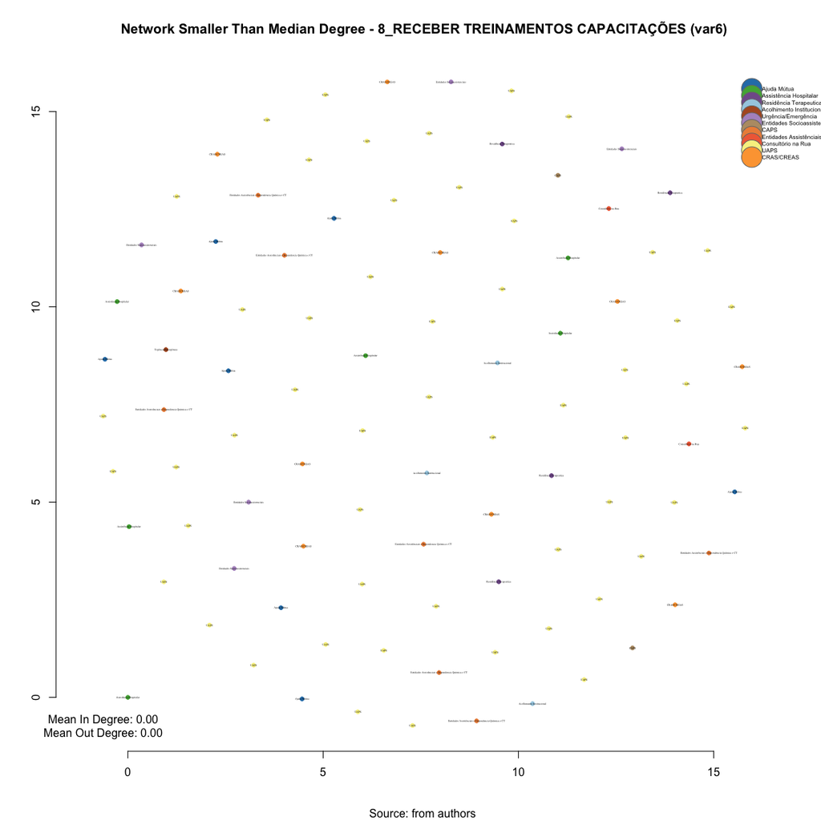

```r
#Set Seed
set.seed(123)

# Network elements with lower than meadian degree
lowerthanmedian.network_var6<-V(var6)[degree(var6)>median(degree(var6))]

#Deleting vertices based in intersection betewenn var6
small_var6<-delete.vertices(var6, lowerthanmedian.network_var6)

#Plotting based only on degree measures
edge.start <- ends(small_var6, es=E(small_var6), names=F)[,1]

# Fixing ego
minC <- rep(-Inf, vcount(small_var6))
maxC <- rep(Inf, vcount(small_var6))
minC[1] <- maxC[1] <- 0
co <- layout_with_fr(small_var6, niter=10000, minx=minC, maxx=maxC,miny=minC, maxy=maxC, weights = E(small_var6)$weight)

#PLotting
plot(small_var6,
     layout=co,
     edge.color=V(small_var6)$color[edge.start],
     edge.arrow.size=(degree(small_var6)+1)/1000,
     edge.width=E(small_var6)$weight/10,
     edge.curved = TRUE,
     vertex.size=log((V(small_var6)$var6_centr_degree+2))*20,
     vertex.frame.color="#ffffff",
     vertex.label.color="black",
     vertex.label=get.vertex.attribute(small_var6,"LABEL_COR"),
     vertex.label.cex=log((degree(small_var6)+2))/3,
     vertex.label.dist=0,
     rescale=F,
     xlim=range(co[,1]),
     ylim=range(co[,2]))
axis(1)
axis(2)

#Solving Problems with legend rendering
a<-V(small_var6)$LABEL_COR
b<-V(small_var6)$color
c<-table(a,b)
d<-as.data.frame(c)
e<-subset(d, d$Freq>0)
f<-t(e$a)
g<-t(e$b)

#Adding Legend
legend(x=range(co[,1])[2], y=range(co[,2])[2],
       legend=as.character(f),
       pch=21,
       col = "#777777",
       pt.bg=as.character(g),
       pt.cex=4,
       bty="n",
       ncol=1,
       lty=1,
       cex = .5)

#Adding Title
  title("Network Smaller Than Median Degree - 8_RECEBER TREINAMENTOS CAPACITAÇÕES (var6)", sub = "Source: from authors ")
  text(x=range(co[,1])[1], y=range(co[,2])[1], labels =
   sprintf("Mean In Degree: %.2f\nMean Out Degree: %.2f",
     mean(degree(small_var6, mode="in")),
     mean(degree(small_var6, mode="out"))
   )
  )
```

# 18 Plotting using Average Neighbor Degree

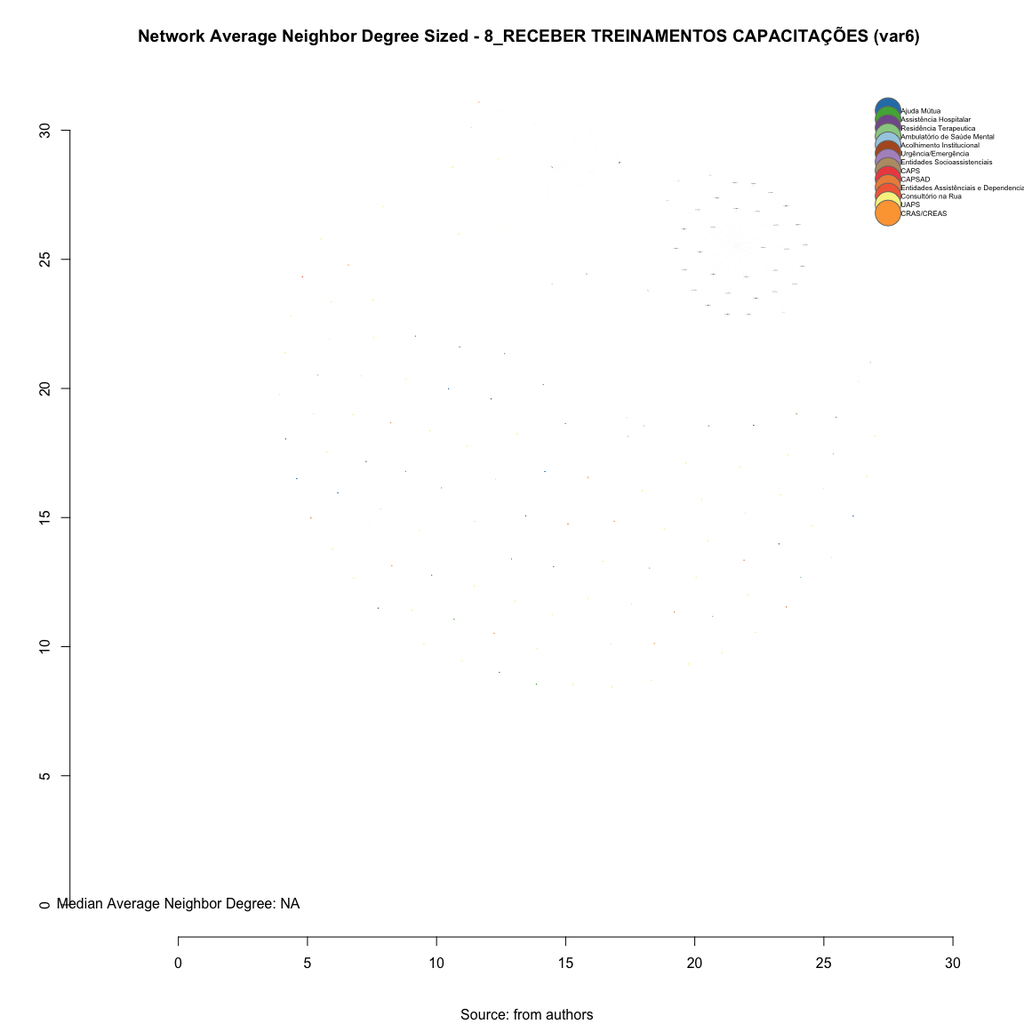

```r
#Set Seed
set.seed(124)

#Plotting based only on degree measures
edge.start <- ends(var6, es=E(var6), names=F)[,1]

# Fixing ego
minC <- rep(-Inf, vcount(var6))
maxC <- rep(Inf, vcount(var6))
minC[1] <- maxC[1] <- 0
co <- layout_with_fr(var6, niter=10000, minx=minC, maxx=maxC,miny=minC, maxy=maxC, weights = E(var6)$weight)

#Plotting based only on degree measures  #var6_a.nn.deg
V(var6)$var6_a.nn.deg<-as.numeric(graph.knn(var6)$knn)
V(var6)$var6_a.nn.deg[V(var6)$var6_a.nn.deg=="NaN"]<-0

#PLotting
plot(high_var6,
     layout=co,
     edge.color=V(var6)$color[edge.start],
     edge.arrow.size=sqrt((V(var6)$var6_a.nn.deg)^2+1)/1000,
     edge.width=E(var6)$weight/100,
     edge.curved = TRUE,
     vertex.color=V(var6)$color,
     vertex.size=(sqrt((V(var6)$var6_a.nn.deg)^2))/5,
     vertex.frame.color="#ffffff",
     vertex.label.color="black",
     vertex.label=get.vertex.attribute(var6,"LABEL_COR"),
     vertex.label.cex=(sqrt((V(var6)$var6_a.nn.deg)^2)+1)/500,
     vertex.label.dist=0,
     rescale=F,
     xlim=range(co[,1]),
     ylim=range(co[,2]))
axis(1)
axis(2)


#Solving Problems with legend rendering
a<-V(var6)$LABEL_COR
b<-V(var6)$color
c<-table(a,b)
d<-as.data.frame(c)
e<-subset(d, d$Freq>0)
f<-t(e$a)
g<-t(e$b)

#Adding Legend
legend(x=range(co[,1])[2], y=range(co[,2])[2],
       legend=as.character(f),
       pch=21,
       col = "#777777",
       pt.bg=as.character(g),
       pt.cex=4,
       bty="n",
       ncol=1,
       lty=1,
       cex = .5)

#Adding Title
  title("Network Average Neighbor Degree Sized - 8_RECEBER TREINAMENTOS CAPACITAÇÕES (var6)", sub = "Source: from authors ")
  text(x=range(co[,1])[1], y=range(co[,2])[1], labels =
   sprintf("Median Average Neighbor Degree: %.2f",
     median((var6_a.nn.deg+1))
   ))
```

# 19 Plotting using Average Neighbor Degree

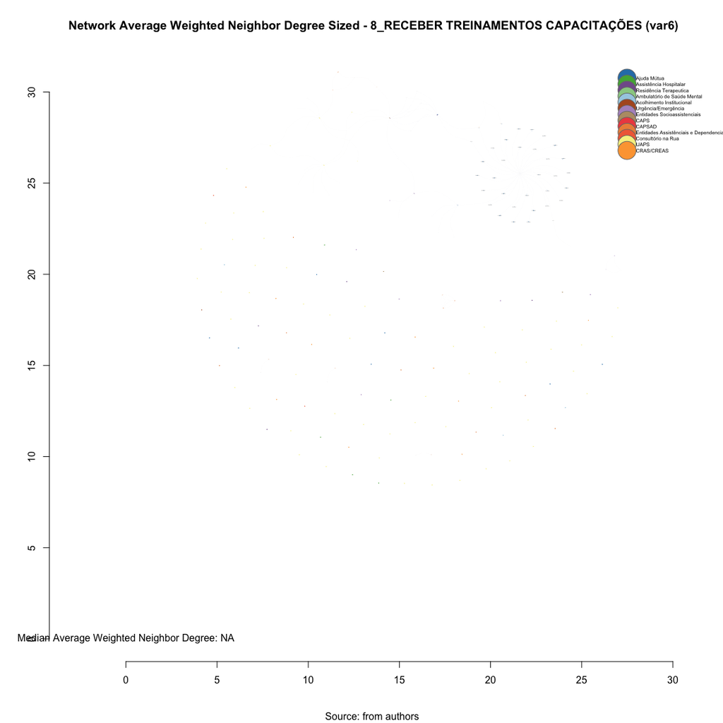

```r
#Set Seed
set.seed(124)

#Plotting based only on degree measures
edge.start <- ends(var6, es=E(var6), names=F)[,1]

# Fixing ego
minC <- rep(-Inf, vcount(var6))
maxC <- rep(Inf, vcount(var6))
minC[1] <- maxC[1] <- 0
co <- layout_with_fr(var6, niter=10000, minx=minC, maxx=maxC,miny=minC, maxy=maxC, weights = E(var6)$weight)


#Plotting based only on degree measures  #var6_a.nn.deg
V(var6)$var6_a.nn.deg_w<-as.numeric(graph.knn(var6, weights = E(var6)$weight)$knn)
V(var6)$var6_a.nn.deg_w[V(var6)$var6_a.nn.deg_w=="NaN"]<-0

#PLotting
plot(high_var6,
     layout=co,
     edge.color=V(var6)$color[edge.start],
     edge.arrow.size=sqrt((V(var6)$var6_a.nn.deg_w)^2+1)/1000,
     edge.width=E(var6)$weight/100,
     edge.curved = TRUE,
     vertex.color=V(var6)$color,
     vertex.size=(sqrt((V(var6)$var6_a.nn.deg_w)^2))/5,
     vertex.frame.color="#ffffff",
     vertex.label.color="black",
     vertex.label=get.vertex.attribute(var6,"LABEL_COR"),
     vertex.label.cex=(sqrt((V(var6)$var6_a.nn.deg_w)^2)+1)/500,
     vertex.label.dist=0,
     rescale=F,
     xlim=range(co[,1]),
     ylim=range(co[,2]))
axis(1)
axis(2)


#Solving Problems with legend rendering
a<-V(var6)$LABEL_COR
b<-V(var6)$color
c<-table(a,b)
d<-as.data.frame(c)
e<-subset(d, d$Freq>0)
f<-t(e$a)
g<-t(e$b)

#Adding Legend
legend(x=range(co[,1])[2], y=range(co[,2])[2],
       legend=as.character(f),
       pch=21,
       col = "#777777",
       pt.bg=as.character(g),
       pt.cex=4,
       bty="n",
       ncol=1,
       lty=1,
       cex = .5)

#Adding Title
  title("Network Average Weighted Neighbor Degree Sized - 8_RECEBER TREINAMENTOS CAPACITAÇÕES (var6)", sub = "Source: from authors ")
  text(x=range(co[,1])[1], y=range(co[,2])[1], labels =
   sprintf("Median Average Weighted Neighbor Degree: %.2f",
     median((var6_a.nn.deg_w+1))
   ))
```

# 20 Circle Degree *Too intensive computation* #code

```r
#Circle Degree ***Too intense computation***
#A_var6 <- get.adjacency(var6, sparse=FALSE)
#detach("package:igraph", unload=TRUE)
#library(network)
#g <- network::as.network.matrix(A_var6)
#library(sna)
#gplot.target(g, degree(g), main="Circle Degree")
#library(igraph)
```

# 21 Saving objects with new variables and changes

```r
save.image("~/SNArRDJF/Robject/2_degree_var6.RData")
```